# HW_2

Nikitin Dmitry RI-450004

5 октября 2018 г

### Загрузка и очистка данных

- Загрузите данные в датафрейм, который назовите `data`.

```r
data = read.csv(file="https://raw.githubusercontent.com/SergeyMirvoda/da2016/master/data/calif_penn_2011.csv")
```

- Сколько строк и столбцов в `data`?

```r
nrow(data)
```

```
## [1] 11275
```

```r
ncol(data)
```

```
## [1] 34
```

- Выполните команду и объясните, что она делает. Данная команда считает значение NA в каждой колонке.

```r
colSums(apply(data, c(1,2), is.na))
```

```
##                           X                     GEO.id2
##                           0                           0
##                     STATEFP                    COUNTYFP
##                           0                           0
##                     TRACTCE                  POPULATION
##                           0                           0
##                    LATITUDE                   LONGITUDE
##                           0                           0
##           GEO.display.label          Median_house_value
##                           0                         599
##                 Total_units                Vacant_units
##                           0                           0
##                Median_rooms  Mean_household_size_owners
##                         157                         215
## Mean_household_size_renters         Built_2005_or_later
##                         152                          98
##          Built_2000_to_2004                 Built_1990s
##                          98                          98
##                 Built_1980s                 Built_1970s
##                          98                          98
##                 Built_1960s                 Built_1950s
##                          98                          98
##                 Built_1940s       Built_1939_or_earlier
##                          98                          98
##                  Bedrooms_0                  Bedrooms_1
##                          98                          98
##                  Bedrooms_2                  Bedrooms_3
##                          98                          98
##                  Bedrooms_4          Bedrooms_5_or_more
##                          98                          98
##                      Owners                     Renters
##                         100                         100
##     Median_household_income       Mean_household_income
##                         115                         126
```

- Функция `na.omit()` принимает датафрейм и возвращает новый датафрейм, игнорируя строки, содержащие значение *NA*. Используйте эту функцию для удаления строк с неполными данными.

```r
without.na.data = na.omit(data)
```

- Сколько строк было удалено?

```r
nrow(data) - nrow(without.na.data)
```

```
## [1] 670
```

- Соответствует ли результат выполнения, значениям из пункта 3? na.omit(data) удаляет каждую строку в которой встретилось na, при этом команда из пункта 3 показывает количество na в каждой колонке максимальное количество na в одной из колонок 599 это означает что в 599 строках этой колонки втретилось na при этом в других колнках, где нет пересечений с этими строками также может втретиться na, т.о результат может соответствоавть а может и нет. ### Новые дома
- Переменная(колонка) *Built_2005_or_later* содержит данные о проценте домов, построенных с 2005 года. Постройте диаграмму рассеяния (scatterplot) медианы стоимости домов (переменная *Median_house_value*) относительно процента новых домов.

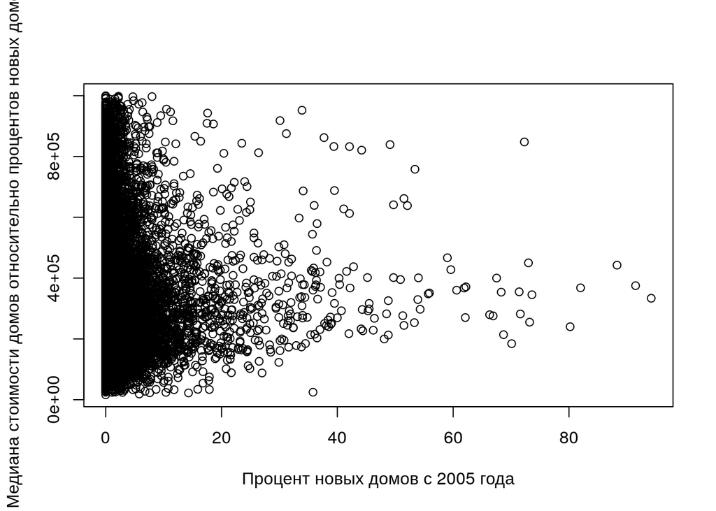

```r
plot(without.na.data$Built_2005_or_later, without.na.data$Median_house_value, xlab="Процент новых домов с 2005 года", ylab="Медиана стоимости домов относительно процентов новых домов")
```

* Постройте ещё два графика для каждого из штатов отдельно. Номер штата содержится в переменной (*STATEFP*), где Калифорния 6-й штат, а Пенсильвания 42.

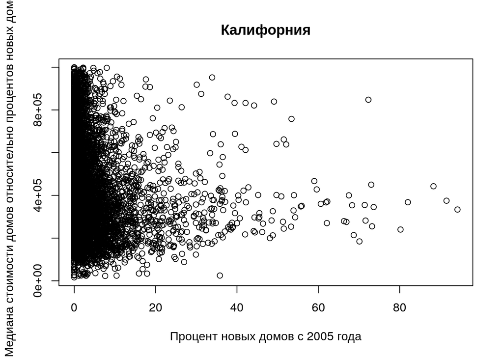

```r
california <- without.na.data[without.na.data$STATEFP==6,]
pensilvania <- without.na.data[without.na.data$STATEFP==42,]
plot(california$Built_2005_or_later, california$Median_house_value, xlab="Процент новых домов с 2005 года", ylab="Медиана стоимости домов относительно процентов новых домов", main="Калифорния")
```

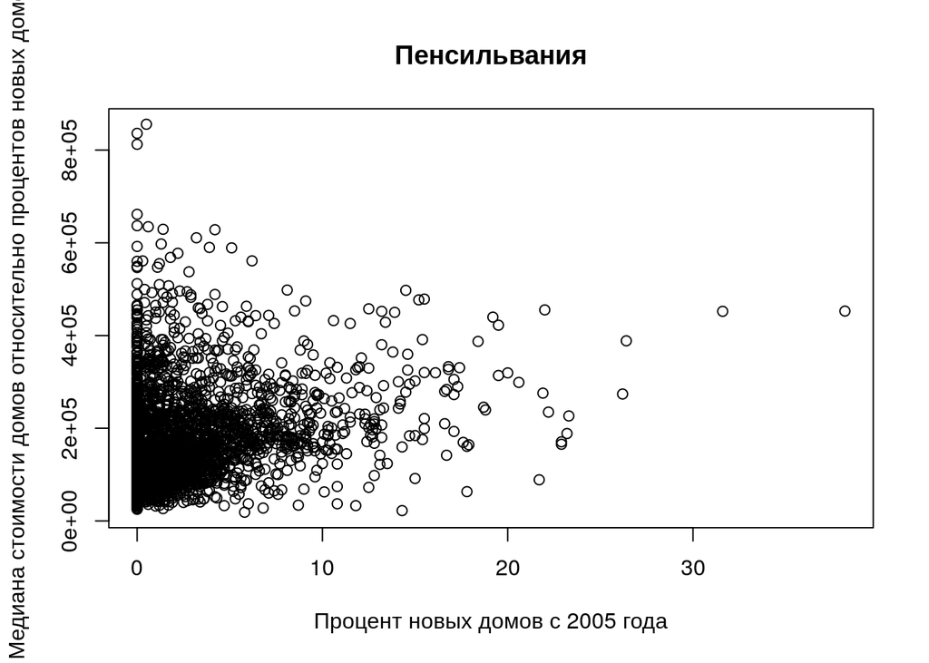

```r
plot(pensilvania$Built_2005_or_later, pensilvania$Median_house_value, xlab="Процент новых домов с 2005 года", ylab="Медиана стоимости домов относительно процентов новых домов", main="Пенсильвания")
```

### Незанятые дома Уровень найма (vacancy rate) — доля домов, которые не были заняты. В данных содержатся колонки, содержащие общее количество домовладений и количество не занятых домовладений. * В датафрейм *data* добавьте новую колонку *vacancy_rate*, которая должна содержать вышеописанный показатель.

```r
vacancy_rate <- without.na.data$Vacant_units/without.na.data$Total_units
without.na.data <- cbind(without.na.data, vacancy_rate)
```

- Найдите минимум, максимум, среднее и медиану полученных значений показателя.

```r
min(without.na.data$vacancy_rate)
```

```
## [1] 0
```

```r
max(without.na.data$vacancy_rate)
```

```
## [1] 0.965311
```

```r
mean(without.na.data$vacancy_rate)
```

```
## [1] 0.08888789
```

```r
median(without.na.data$vacancy_rate)
```

```
## [1] 0.06767283
```

- Постройте диаграмму уровня найма относительно медианы стоимости домов. Что можно заметить?

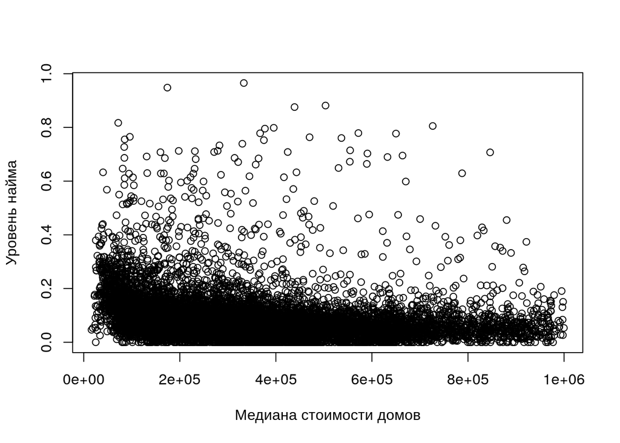

```r
plot(without.na.data$Median_house_value, without.na.data$vacancy_rate, xlab="Медиана стоимости домов", ylab="Уровень найма")
```

Чем выше медиана стоимости тем меньше уровень найма. ### Корреляция Колонка *COUNTYFP* содержит числовой код округа внутри штата. Нас интересуют Butte County (округ 7 в Калифорнии), Santa Clara (округ 85 в Калифорнии) и York County (округ 133 в Пенсильвании). * Объясните, что делает приведённый в конце задания код и как именно он это делает.

```r
ca_pa <- without.na.data
acc <- c()
for (tract in 1:nrow(ca_pa)) {
  if (ca_pa$STATEFP[tract] == 6) {
    if (ca_pa$COUNTYFP[tract] == 1) {
      acc <- c(acc, tract)
    }
  }
}
accmv <- c()
for (tract in acc) {
  accmv <- c(accmv, ca_pa[tract,10])
}
median(accmv)
```

```
## [1] 474050
```

Код находит медиану от Median_house_value в штате Калифорния и округом с номером 1. Для этого построчно в цикле проверяется что номер штата равен 6 а номер округа равен 1, затем на каждом ходе номер строки добавляется в вектор acc, далее в accmv на каждой итерации происходит добавление в accmv происходит добавление Median_house_value из строки с номером в acc. Далее находим медиану от accmv. * Напишите другим способом в одну строку, то же самое, что делает нижеуказанный код. Способов получить тот же ответ множество, достаточно одного.

```r
median(subset(without.na.data[without.na.data$STATEFP==6,], without.na.data[without.na.data$STATEFP==6,]$COUNTYFP==1)$Median_house_value)
```

```
## [1] 474050
```

```r
mean(subset(without.na.data[without.na.data$STATEFP==6,], without.na.data[without.na.data$STATEFP==6,]$COUNTYFP==7)$Median_house_value)
```

```
## [1] 249782.4
```

```r
mean(subset(without.na.data[without.na.data$STATEFP==6,], without.na.data[without.na.data$STATEFP==6,]$COUNTYFP==85)$Median_house_value)
```

```
## [1] 587204.2
```

```r
mean(subset(without.na.data[without.na.data$STATEFP==42,], without.na.data[without.na.data$STATEFP==42,]$COUNTYFP==133)$Median_house_value)
```

```
## [1] 169588.9
```

- Функция `cor` рассчитывает коэффициент кореляции между двумя переменными. Рассчитайте корреляцию между медианы стоимости домовладений (*Median_house_value*) и процентом построенных домов (*Built_2005_or_late*):
1. для всего набора данных
2. для Калифорнии
3. для Пенсильвании
4. для округа Butte County
5. для округа Santa Clara
6. для округа York County

```r
cor(without.na.data$Median_house_value, without.na.data$Built_2005_or_later)
```

```
## [1] -0.01893186
```

```r
cor(california$Median_house_value, california$Built_2005_or_later)
```

```
## [1] -0.1153604
```

```r
cor(pensilvania$Median_house_value, pensilvania$Built_2005_or_later)
```

```
## [1] 0.2681654
```

```r
cor(california[california$COUNTYFP==7,]$Median_house_value, california[california$COUNTYFP==7,]$Built_2005_or_later)
```

```
## [1] 0.04203267
```

```r
cor(california[california$COUNTYFP==85,]$Median_house_value, california[california$COUNTYFP==85,]$Built_2005_or_later)
```

```
## [1] -0.1726203
```

```r
cor(pensilvania[pensilvania$COUNTYFP==133,]$Median_house_value, pensilvania[pensilvania$COUNTYFP==133,]$Built_2005_or_later)
```

```
## [1] 0.3860773
```

- Постройте три диаграммы медианы стоимости домовладений (*Median_house_value*) относительно медианы дохода (*Median_household_income*) для трёх округов. Допустимо указать все три на одном графике.

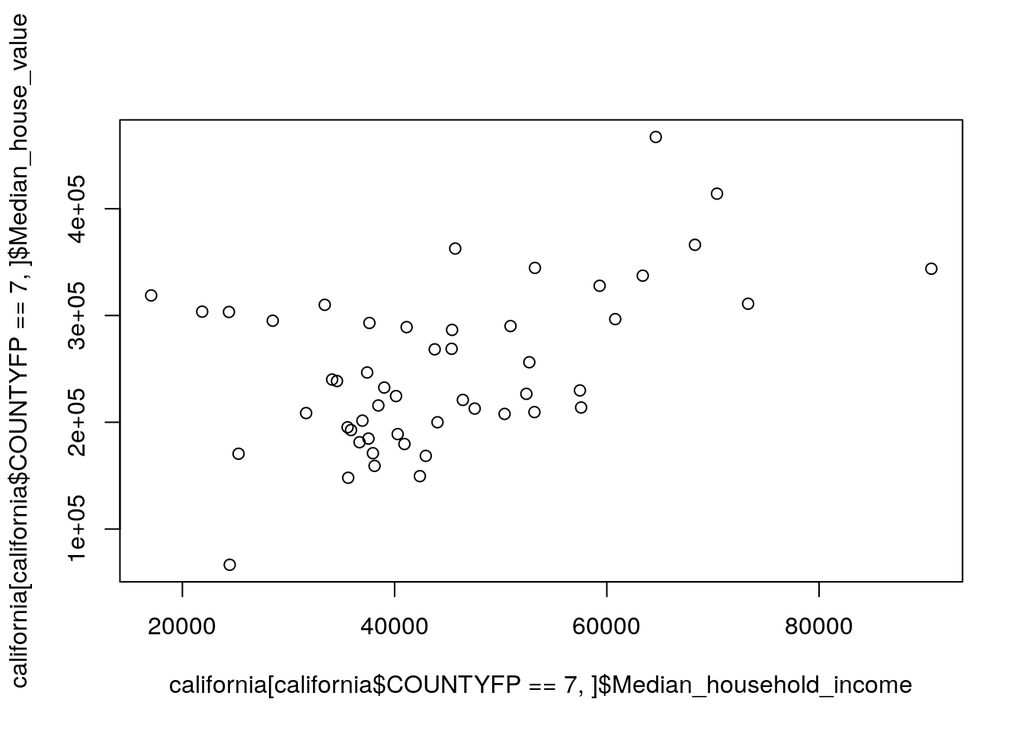

```r
plot(california[california$COUNTYFP==7,]$Median_household_income, california[california$COUNTYFP==7,]$Median_house_value)
```

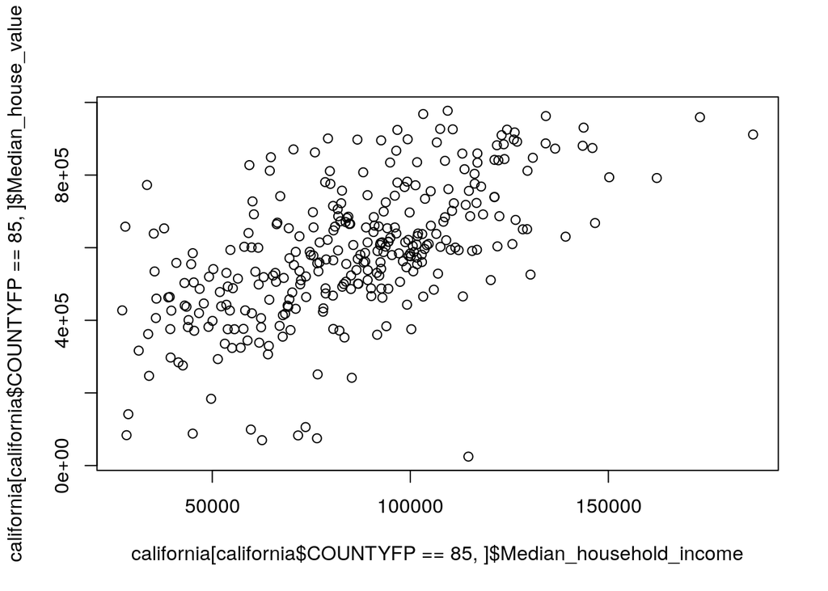

```r
plot(california[california$COUNTYFP==85,]$Median_household_income, california[california$COUNTYFP==85,]$Median_house_value)
```

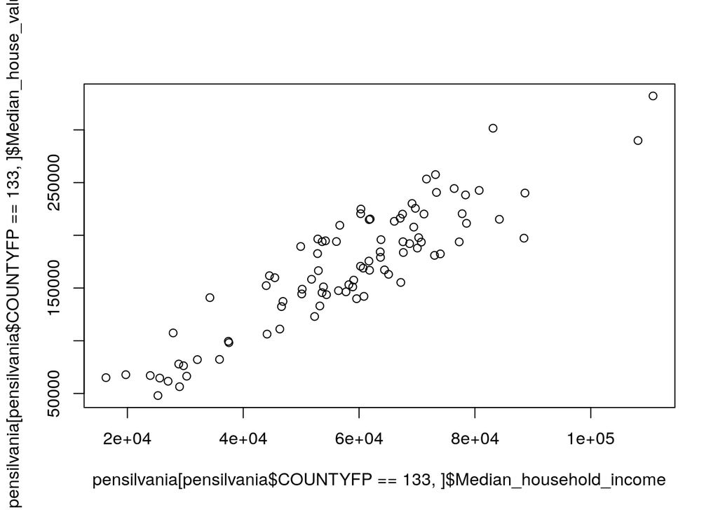

```r
plot(pensilvania[pensilvania$COUNTYFP==133,]$Median_household_income, pensilvania[pensilvania$COUNTYFP==133,]$Median_house_value)
```